# Psy 792F Project

# HI DELLA, READ ME!!!

Hey Della, Neil here. Okay this document contains a bunch of descriptive statistics of our data. From reading over the group project, I realized we really don’t need to get to into deep analysis. However, I have created charts for all of our demographic variables and done some anlalyses. I also sent a complimentary word document into the email and am hoping the answers on that are helpful as well.

Insert an “r-chunk” by clicking “insert” then “R” This is a space for R-coding an is runnable To run this notebook, click “Run” (Upper right) The “Restart R and run all Chuncks. Chunk = exceutable R-code.

# First set up our packages

```r
#install.packages("tydyverse")
#install.packages("psych")
#install.packages("apaTables")
#install.packages("olsrr")

library(tidyverse) #the best package for reading & cleaning data
library(psych) #we use this for relibaility
library(apaTables) #Creates really cool tables (and APA formatted!)
library(olsrr) #<- regression analysis package
```

# Load in the data

```r
survey <- read_csv("Psy_792F.csv")
```

# Research Question / Hypothesis

Is there an association between learning orientation and perceived stress?

**Answer**: There seems to be an associatin between affective learning orientation and perceived stress. However, this is not the case for the behavioral and cognitive subscales

Ho = No difference Ha = There is a difference

All t-tests = two sided.

# Clean the data

```r
survey <- survey %>%
  filter(consent == 1 & over_18 == 1) %>% #selecting only individuals over 18 & consented
  select(-(StartDate:over_18)) #Remove uneccessary variables (start date - Over_18)
```

# Recode & Factor variables

Here I am recoding and labeling our demographic variables for the charts I am about to create

```r
survey <- survey %>%
  mutate(male = ifelse(gender == 2, 0, gender), #recoding gende to male variable. Male = 1, female = 0
         age = (2017 - yrborn), #creating age variable

         male.f = factor(male, levels = c(0,1), labels = c("Female", "Male")), #factoring and labeling "male"


        sexor = (ifelse(sexor == 5, 2, sexor)), # combining Gay/lesbian... category = homosexual
        sexor.f = factor(sexor, levels = c(1,2,3,6), labels = c("Heterosexual", "Homosexual", "Bisexual", "Other")), #factoring and labeling sexual orientation

        income.f = factor(income, levels = c(1,2,3,4,5,6), labels = c("< $20k", "$20k to $39k", "$40k - $59k", "$60k - $79k", "$80k - $99k", "$100k +")), #factoring and labeling income
        educ.f = factor(educ, levels = c(1:6), labels = c("Grade school", "High school diploma", "Some college", "Associates Degree", "Bacholer's Degree", "Post Bachelors degree")), #labeling and factoring udcation level
        edu_di = ifelse(educ >= 5, 1, 0),
        edu_di.f = factor(edu_di, c(1,0), labels = c("obtained a 4-year college degree", "No college")), #Dichotomizing education

        marstat.f = factor(marstat, levels = (1:6), labels = c("Single", "Married", "Not married,living w/ partner", "Seperated", "Divorced", "Widowed")), #factroing and leveling marriage status
        marstat_di = ifelse(marstat == 2, 1, 0), #dichotomizing marstatus, 1 = married 0 = single
        marstat_di.f = factor(marstat_di, levels = c(0,1), labels = c("Single", "Married")))  #factoring and labeling dichotomized marriage status
```

## Recode and factor race

Race was a little it more difficult to recode…

```r
####Special recode for race 0 = No response, , 1 = "Amer Indian" 2 = "Asian", "3" = "Black", 4 = "Hispanic", 5 = "Hawian/PI",, 6 = "White", 7 = "Other", 8 = "Mixed Race"
survey <- survey %>%
 mutate(race_1 = ifelse(is.na(race_1), 0, 1))%>%
 mutate(race_2 = ifelse(is.na(race_2), 0, 2)) %>%
 mutate(race_3 = ifelse(is.na(race_3), 0, 3)) %>%
 mutate(race_4 = ifelse(is.na(race_4), 0, 4)) %>%
 mutate(race_5 = ifelse(is.na(race_5), 0, 5)) %>%
 mutate(race_6 = ifelse(is.na(race_6), 0, 6)) %>%
 mutate(race_7 = ifelse(is.na(race_7), 0, 7)) %>%
  rowwise() %>%
 mutate(race_temp = sum(race_1, race_2, race_3, race_4, race_5, race_6, race_7),
         race = ifelse(race_temp > 7, 8, race_temp),
        race.f = factor(race, levels= c(0,8,1,5,2,3,4,6,7), labels = c("No response","Mixed Race", "American Indian or Alaska Native", "Native Hawaiian Other Pacific Islander","Asian","Black/African American", "Hispanic/Latino", "White", "Other"))) #Reorder so it looked better on the bar chart (semi-descending order with mixed and no response on bottom.)
```

# Tables for demograhic variables

```r
#Age summary
summary(survey$age)
```

```
##    Min. 1st Qu.  Median    Mean 3rd Qu.    Max.    NA's
##   20.00   25.00   26.00   27.83   28.00   53.00       2
```

```r
# race frequencies
table(survey$race.f)
```

```
##
##                            No response
##                                      1
##                             Mixed Race
##                                      9
##       American Indian or Alaska Native
##                                      0
## Native Hawaiian Other Pacific Islander
##                                      1
##                                  Asian
##                                      3
##                 Black/African American
##                                      4
##                        Hispanic/Latino
##                                     17
##                                  White
##                                     43
##                                  Other
##                                      0
```

```r
#sex frequencies
table(survey$male.f)
```

```
##
## Female   Male
##     56     21
```

```r
#marital status frequencies
table(survey$marstat.f)
```

```
##
##                        Single                       Married
##                            42                            14
## Not married,living w/ partner                     Seperated
##                            21                             0
##                      Divorced                       Widowed
##                             0                             0
```

```r
#Sexual orientation table
table(survey$sexor.f)
```

```
##
## Heterosexual   Homosexual     Bisexual        Other
##           66            5            6            0
```

```r
#education frequencies
table(survey$educ.f)
```

```
##
##          Grade school   High school diploma          Some college
##                     0                    11                    13
##     Associates Degree     Bacholer's Degree Post Bachelors degree
##                     1                    22                    30
```

# Charts and graphs!

## AGE

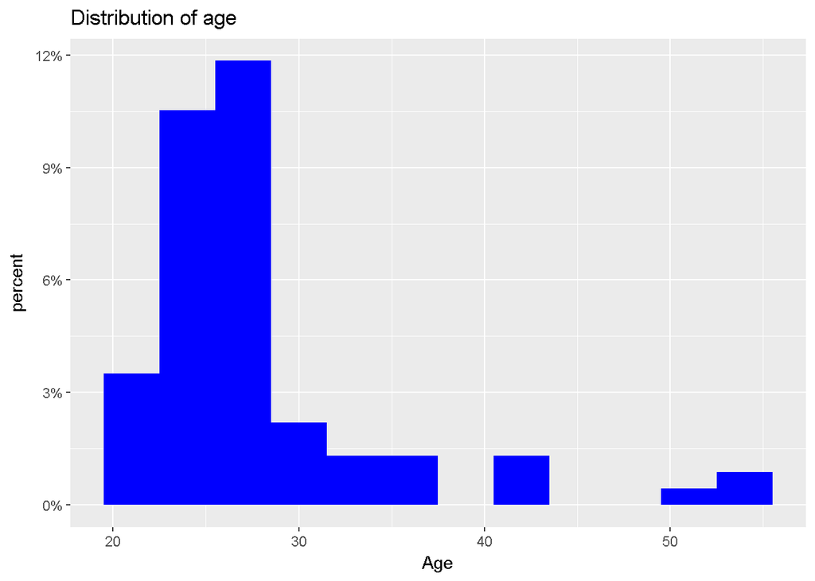

```r
ggplot(survey, aes(x = age)) +
  geom_histogram(aes(y = (..density..)*100), binwidth = 3, fill = "blue") +
  labs(title = "Distribution of age", y = "percent", x = "Age")  + scale_y_continuous(labels = function(x){ paste0(x, "%") })
```

## race plot

### Percentage

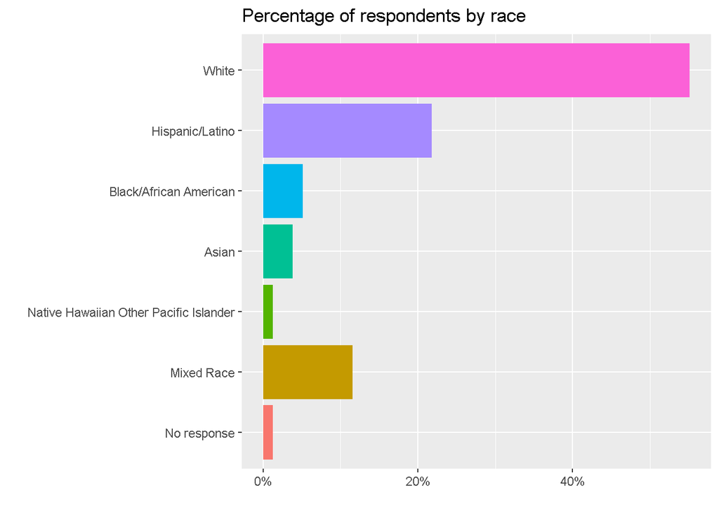

```r
ggplot(survey, aes(race.f)) +
  geom_bar( aes(fill = race.f, y = (..count..)/sum(..count..)*100) , position = position_stack(reverse =TRUE)) +
  coord_flip() + theme(legend.position="none") +
  labs(title = "Percentage of respondents by race", x="", y = "") + scale_y_continuous(labels = function(x){ paste0(x, "%") })
```

### Count

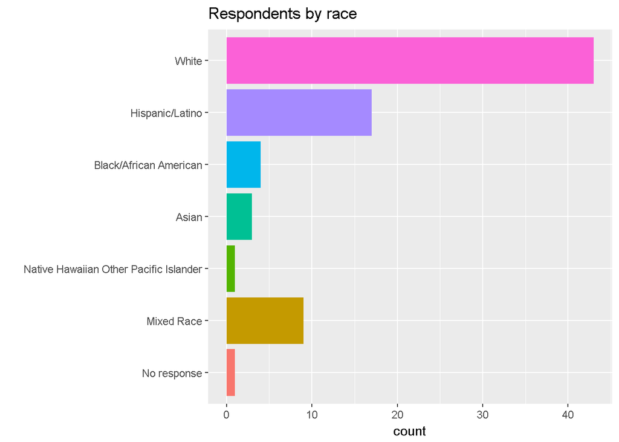

```r
ggplot(survey, aes(race.f)) +
  geom_bar( aes(fill = race.f) , position = position_stack(reverse =TRUE)) +
  coord_flip() + theme(legend.position="none") +
  labs(title = "Respondents by race", x="")
```

## Gender

### Count

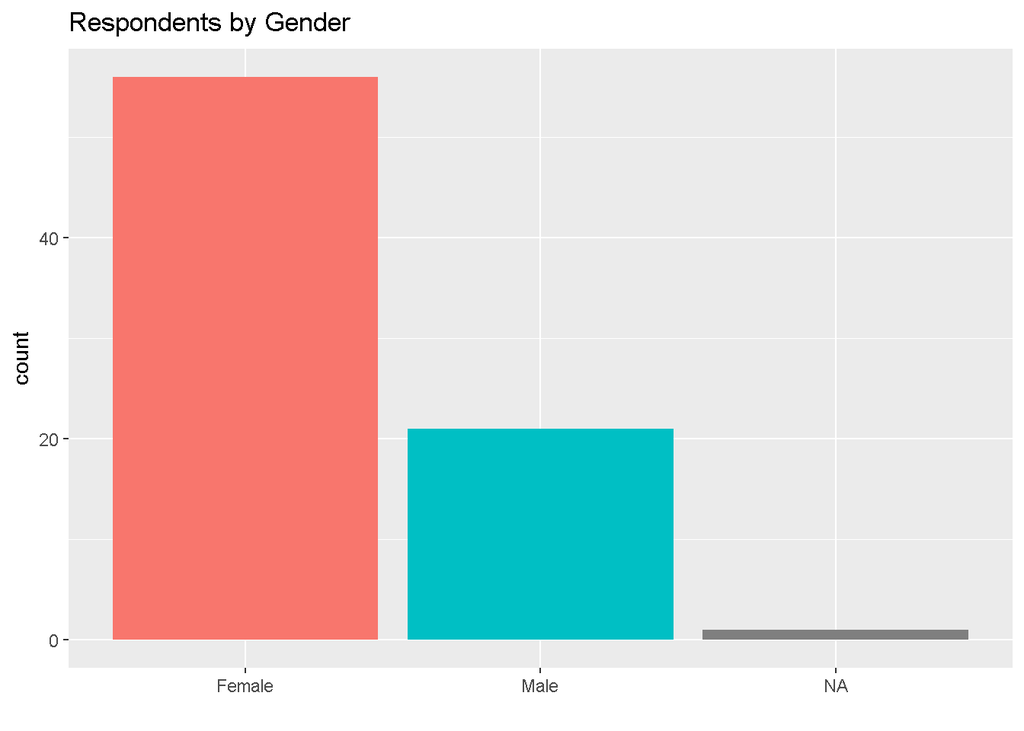

```r
ggplot(survey, aes(male.f)) +
  geom_bar(aes(fill = male.f)) +
  theme(legend.position = "none") + labs( title = "Respondents by Gender", x = "")
```

### Percentag

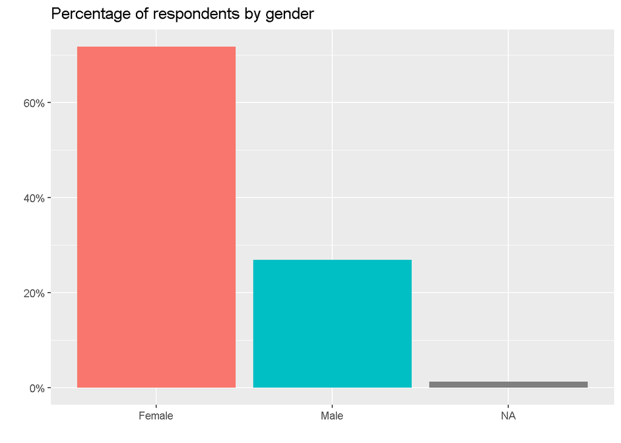

```r
ggplot(survey, aes(male.f)) +
  geom_bar( aes(fill = male.f, y = (..count..)/sum(..count..)*100))  +
  theme(legend.position="none") +
  labs(title = "Percentage of respondents by gender", x="", y = "") + scale_y_continuous(labels = function(x){ paste0(x, "%") })
```

## Sexual Orientation

### Count

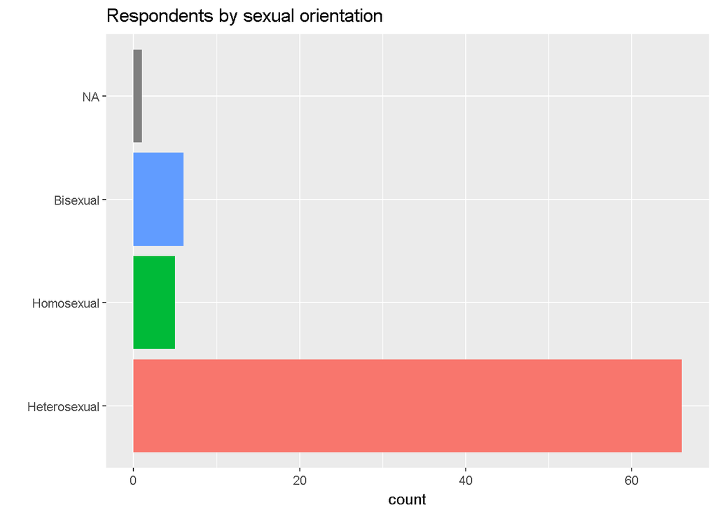

```r
ggplot(survey, aes(sexor.f)) +
  geom_bar(aes(fill = sexor.f) , position = position_stack(reverse =TRUE)) +
  coord_flip() + theme(legend.position="none") +
  labs(title = "Respondents by sexual orientation", x="")
```

### Percentage

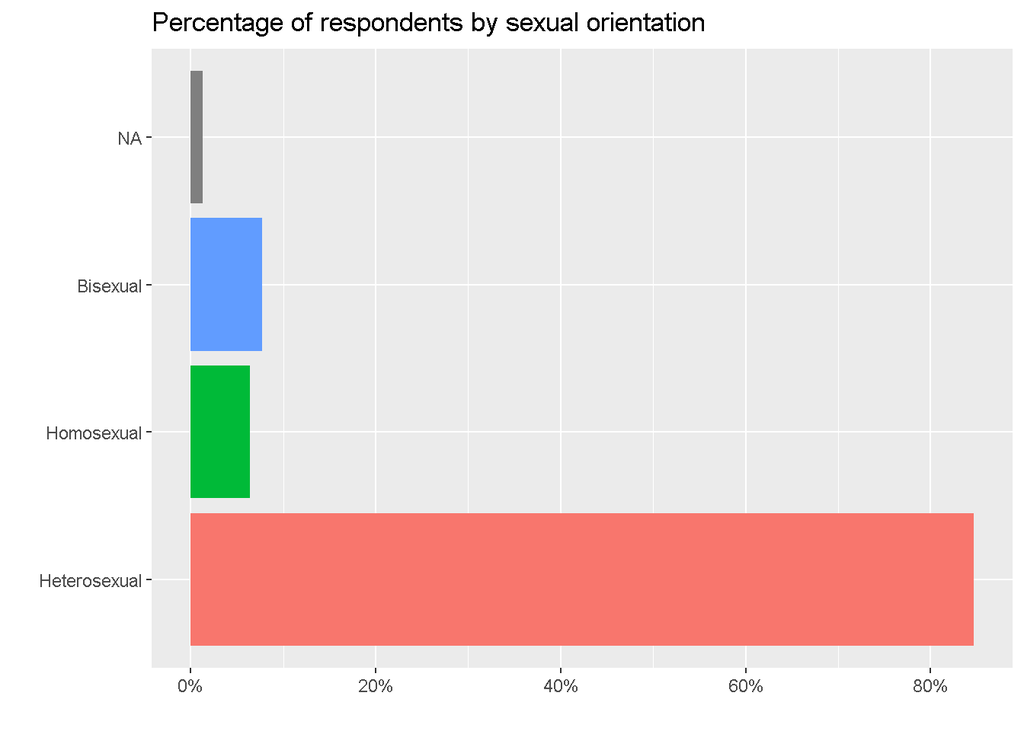

```r
ggplot(survey, aes(sexor.f)) +
  geom_bar( aes(fill = sexor.f, y = (..count..)/sum(..count..)*100) , position = position_stack(reverse =TRUE)) +
  coord_flip() + theme(legend.position="none") +
  labs(title = "Percentage of respondents by sexual orientation", x="", y = "") + scale_y_continuous(labels = function(x){ paste0(x, "%") })
```

## Marital Status

### Count

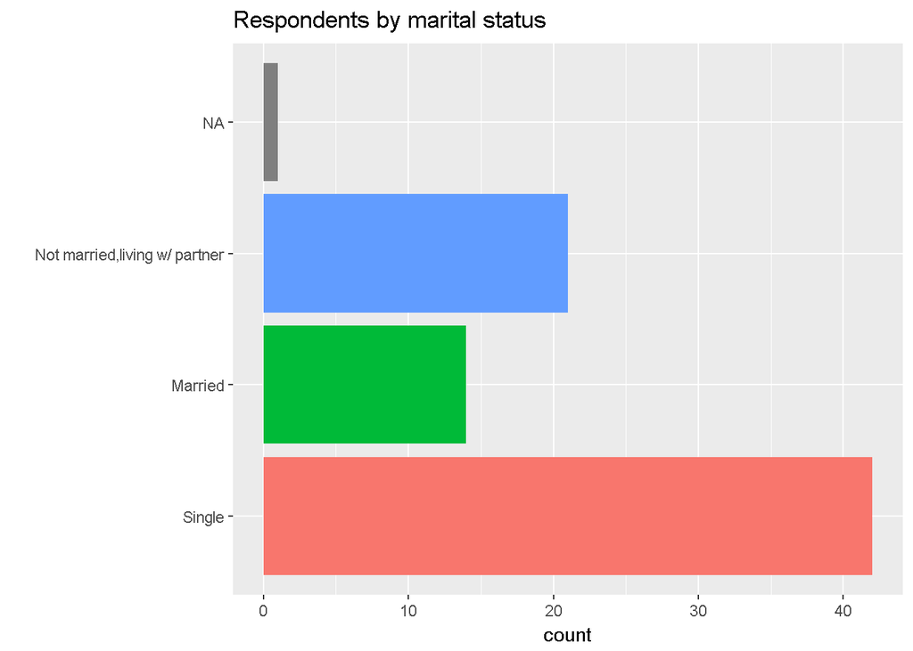

```r
ggplot(survey, aes(marstat.f)) +
  geom_bar(aes(fill = marstat.f) , position = position_stack(reverse =TRUE)) +
  coord_flip() + theme(legend.position="none") +
  labs(title = "Respondents by marital status", x="")
```

### Percent

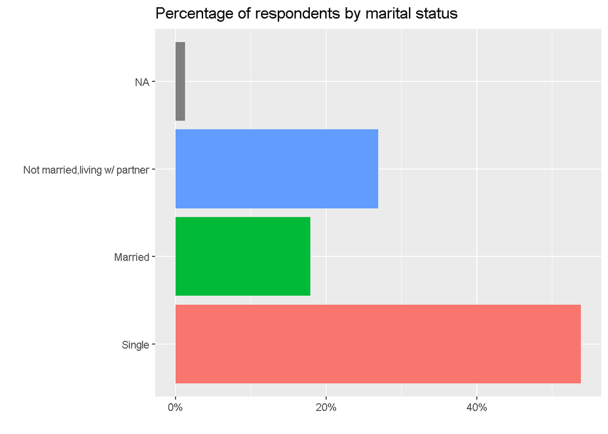

```r
ggplot(survey, aes(marstat.f)) +
  geom_bar( aes(fill = marstat.f, y = (..count..)/sum(..count..)*100) , position = position_stack(reverse =TRUE)) +
  coord_flip() + theme(legend.position="none") +
  labs(title = "Percentage of respondents by marital status", x="", y = "") + scale_y_continuous(labels = function(x){ paste0(x, "%") })
```

## Education

### Count

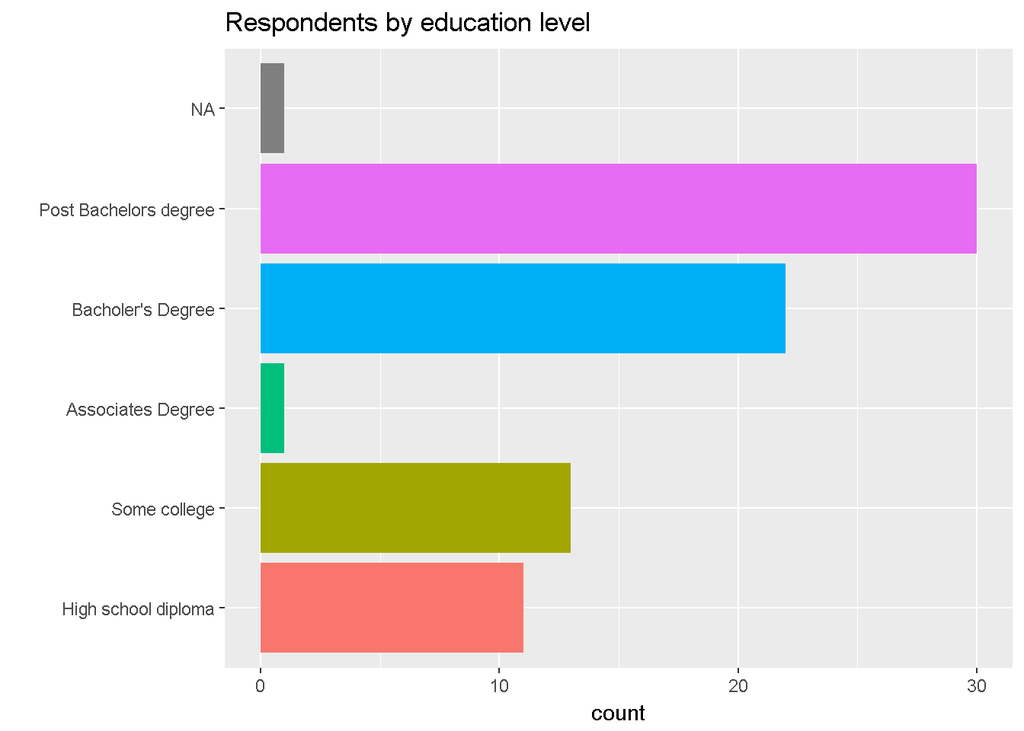

```r
ggplot(survey, aes(educ.f)) +
  geom_bar(aes(fill = educ.f) , position = position_stack(reverse =TRUE)) +
  coord_flip() + theme(legend.position="none") +
  labs(title = "Respondents by education level", x="")
```

### Percent

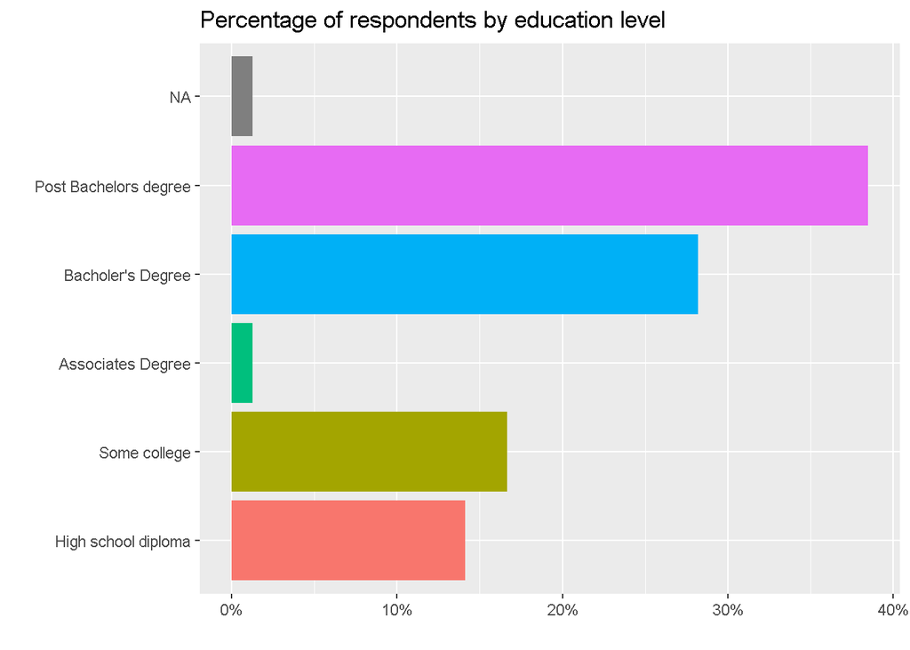

```r
ggplot(survey, aes(educ.f)) +
  geom_bar( aes(fill = educ.f, y = (..count..)/sum(..count..)*100) , position = position_stack(reverse =TRUE)) +
  coord_flip() + theme(legend.position="none") +
  labs(title = "Percentage of respondents by education level", x="", y = "") + scale_y_continuous(labels = function(x){ paste0(x, "%") })
```